# Project: Investigate a Dataset - TMDb movie data

- Introduction
- Data Wrangling
- Exploratory Data Analysis
- Conclusions

## Introduction

This data set contains information about 10,000 movies collected from The Movie Database (TMDb), including user ratings and revenue.  
● Certain columns, like ‘cast’ and ‘genres’, contain multiple values separated by pipe (|) characters.  
● There are some odd characters in the ‘cast’ column. Don’t worry about cleaning them. You can leave them as is.  
● The final two columns ending with “_adj” show the budget and revenue of the associated movie in terms of 2010 dollars, accounting for inflation over time.

### Dataset Description

Bellow you will findout a CSV file, that is the main file we will analize in this present dataset.

### Question(s) for Analysis in the present DataSet

- Which genres are most popular from year to year?
- Which movies had lowest and largest price(budget)?
- What kinds of properties are associated with movies that have high revenues?
- Which movie had the highest or lowest Profit?
- Which year had the highest release of movies?
- Which Movie had longest and shortest runtime?

```python
# Use this cell to set up import statements for all of the packages that you
#   plan to use.
import pandas as ps
import numpy as np
import matplotlib.pyplot as plot
import seaborn as sb
import pprint
#for the plot lines style
sb.set(style="darkgrid")
# Remember to include a 'magic word' so that your visualizations are plotted
#   inline with the notebook. See this page for more:
#   http://ipython.readthedocs.io/en/stable/interactive/magics.html
%matplotlib inline
```

```python
# Upgrade pandas to use dataframe.explode() function.
!pip install --upgrade pandas==0.25.0
```

## Data Wrangling

### General Properties

Bellow we are fetching data from the Database, to use in our analisis in the dataset

```python
# Load your data and print out a few lines. Perform operations to inspect data
#   types and look for instances of missing or possibly errant data.

fetch = ps.read_csv('Database_TMDb_movie_data/tmdb-movies.csv')
fetch.head()
```

|  | id | imdb_id | popularity | budget | revenue | original_title | cast | homepage | director | tagline | ... | overview | runtime | genres | production_companies | release_date | vote_count | vote_average | release_year | budget_adj | revenue_adj |
| --- | --- | --- | --- | --- | --- | --- | --- | --- | --- | --- | --- | --- | --- | --- | --- | --- | --- | --- | --- | --- | --- |
| 0 | 135397 | tt0369610 | 32.985763 | 150000000 | 1513528810 | Jurassic World | Chris Pratt\|Bryce Dallas Howard\|Irrfan Khan\|Vi... | http://www.jurassicworld.com/ | Colin Trevorrow | The park is open. | ... | Twenty-two years after the events of Jurassic ... | 124 | Action\|Adventure\|Science Fiction\|Thriller | Universal Studios\|Amblin Entertainment\|Legenda... | 6/9/15 | 5562 | 6.5 | 2015 | 1.379999e+08 | 1.392446e+09 |
| 1 | 76341 | tt1392190 | 28.419936 | 150000000 | 378436354 | Mad Max: Fury Road | Tom Hardy\|Charlize Theron\|Hugh Keays-Byrne\|Nic... | http://www.madmaxmovie.com/ | George Miller | What a Lovely Day. | ... | An apocalyptic story set in the furthest reach... | 120 | Action\|Adventure\|Science Fiction\|Thriller | Village Roadshow Pictures\|Kennedy Miller Produ... | 5/13/15 | 6185 | 7.1 | 2015 | 1.379999e+08 | 3.481613e+08 |
| 2 | 262500 | tt2908446 | 13.112507 | 110000000 | 295238201 | Insurgent | Shailene Woodley\|Theo James\|Kate Winslet\|Ansel... | http://www.thedivergentseries.movie/#insurgent | Robert Schwentke | One Choice Can Destroy You | ... | Beatrice Prior must confront her inner demons ... | 119 | Adventure\|Science Fiction\|Thriller | Summit Entertainment\|Mandeville Films\|Red Wago... | 3/18/15 | 2480 | 6.3 | 2015 | 1.012000e+08 | 2.716190e+08 |
| 3 | 140607 | tt2488496 | 11.173104 | 200000000 | 2068178225 | Star Wars: The Force Awakens | Harrison Ford\|Mark Hamill\|Carrie Fisher\|Adam D... | http://www.starwars.com/films/star-wars-episod... | J.J. Abrams | Every generation has a story. | ... | Thirty years after defeating the Galactic Empi... | 136 | Action\|Adventure\|Science Fiction\|Fantasy | Lucasfilm\|Truenorth Productions\|Bad Robot | 12/15/15 | 5292 | 7.5 | 2015 | 1.839999e+08 | 1.902723e+09 |
| 4 | 168259 | tt2820852 | 9.335014 | 190000000 | 1506249360 | Furious 7 | Vin Diesel\|Paul Walker\|Jason Statham\|Michelle ... | http://www.furious7.com/ | James Wan | Vengeance Hits Home | ... | Deckard Shaw seeks revenge against Dominic Tor... | 137 | Action\|Crime\|Thriller | Universal Pictures\|Original Film\|Media Rights ... | 4/1/15 | 2947 | 7.3 | 2015 | 1.747999e+08 | 1.385749e+09 |

5 rows × 21 columns

### Raw Obsevations from the Dataset

> I. The present dataset has no unit of currency is mentioned. In this way I will take it as metical (MZN) as it is the coin name used in my country;

> II. We cannot directly conculed the popularity of the movies based on the average vote count, because vote_count is different for all the movies;

> III. I found 3 important column bellow: “budget”, “revenue” and “popularity”, that will be useful for this analysis and we are going to calculate the profit extract the revenue from the budget column;

> IV. We need to handle missing values from budget and revenue column before the calculation;

> I found too, the follow important columns :“director”, “original_title” & “cast”, that have useful information about the movies. “release_date”, and “release_year” columns also important. And we need the convert the release_date column to pandas DateTime object;

> VI. The follow columns: (“homepage”, “tagline”, “keywords”, “overview”, “vote_average”, “budget_adj”, “revenue_adj”) have unuseful information about the movies for this analysis, so these columns could be deleted.

```python
#Shape of data exploration
fetch.shape
```

```
(10866, 21)
```

This table data have a number of movies iqual to **10866** rows and table information divided in **21** columns

```python
#We will verify if there is any empty or null value & get the data types of the varibales.
fetch.info()
```

```
<class 'pandas.core.frame.DataFrame'>
RangeIndex: 10866 entries, 0 to 10865
Data columns (total 21 columns):
 #   Column                Non-Null Count  Dtype
---  ------                --------------  -----
 0   id                    10866 non-null  int64
 1   imdb_id               10856 non-null  object
 2   popularity            10866 non-null  float64
 3   budget                10866 non-null  int64
 4   revenue               10866 non-null  int64
 5   original_title        10866 non-null  object
 6   cast                  10790 non-null  object
 7   homepage              2936 non-null   object
 8   director              10822 non-null  object
 9   tagline               8042 non-null   object
 10  keywords              9373 non-null   object
 11  overview              10862 non-null  object
 12  runtime               10866 non-null  int64
 13  genres                10843 non-null  object
 14  production_companies  9836 non-null   object
 15  release_date          10866 non-null  object
 16  vote_count            10866 non-null  int64
 17  vote_average          10866 non-null  float64
 18  release_year          10866 non-null  int64
 19  budget_adj            10866 non-null  float64
 20  revenue_adj           10866 non-null  float64
dtypes: float64(4), int64(6), object(11)
memory usage: 1.7+ MB
```

### About Duplicates

```python
#Duplicates verification
fetch.duplicated().sum()
```

```
1
```

```python
#Showing duplicates
fetch[fetch.duplicated()]
```

|  | id | imdb_id | popularity | budget | revenue | original_title | cast | homepage | director | tagline | ... | overview | runtime | genres | production_companies | release_date | vote_count | vote_average | release_year | budget_adj | revenue_adj |
| --- | --- | --- | --- | --- | --- | --- | --- | --- | --- | --- | --- | --- | --- | --- | --- | --- | --- | --- | --- | --- | --- |
| 2090 | 42194 | tt0411951 | 0.59643 | 30000000 | 967000 | TEKKEN | Jon Foo\|Kelly Overton\|Cary-Hiroyuki Tagawa\|Ian... | NaN | Dwight H. Little | Survival is no game | ... | In the year of 2039, after World Wars destroy ... | 92 | Crime\|Drama\|Action\|Thriller\|Science Fiction | Namco\|Light Song Films | 3/20/10 | 110 | 5.0 | 2010 | 30000000.0 | 967000.0 |

1 rows × 21 columns

The present dataset has **1** duplicated row of movie information

I found some objects with missing values inside the present dataset

### Data Cleaning

```python
# After discussing the structure of the data and any problems that need to be
#   cleaned, perform those cleaning steps in the second part of this section.
fetch.drop_duplicates(inplace = True)
fetch.shape
```

```
(10865, 21)
```

```python
sum(fetch.duplicated())
```

```
0
```

The present dataset has **0** duplicated lines of information after the drop.

### Drop unused columns

```python
# Removing unnecessary columnns
fetch.drop(['cast','homepage','tagline','overview','production_companies','keywords','budget_adj','revenue_adj'], axis=1, inplace = True)
fetch.head()
```

|  | id | imdb_id | popularity | budget | revenue | original_title | director | runtime | genres | release_date | vote_count | vote_average | release_year |
| --- | --- | --- | --- | --- | --- | --- | --- | --- | --- | --- | --- | --- | --- |
| 0 | 135397 | tt0369610 | 32.985763 | 150000000 | 1513528810 | Jurassic World | Colin Trevorrow | 124 | Action\|Adventure\|Science Fiction\|Thriller | 6/9/15 | 5562 | 6.5 | 2015 |
| 1 | 76341 | tt1392190 | 28.419936 | 150000000 | 378436354 | Mad Max: Fury Road | George Miller | 120 | Action\|Adventure\|Science Fiction\|Thriller | 5/13/15 | 6185 | 7.1 | 2015 |
| 2 | 262500 | tt2908446 | 13.112507 | 110000000 | 295238201 | Insurgent | Robert Schwentke | 119 | Adventure\|Science Fiction\|Thriller | 3/18/15 | 2480 | 6.3 | 2015 |
| 3 | 140607 | tt2488496 | 11.173104 | 200000000 | 2068178225 | Star Wars: The Force Awakens | J.J. Abrams | 136 | Action\|Adventure\|Science Fiction\|Fantasy | 12/15/15 | 5292 | 7.5 | 2015 |
| 4 | 168259 | tt2820852 | 9.335014 | 190000000 | 1506249360 | Furious 7 | James Wan | 137 | Action\|Crime\|Thriller | 4/1/15 | 2947 | 7.3 | 2015 |

### Drop missing data

```python
#Checking if have any N/A data in the dataset
fetch.dropna(inplace=True)
fetch.info()
```

```
<class 'pandas.core.frame.DataFrame'>
Int64Index: 10795 entries, 0 to 10865
Data columns (total 13 columns):
 #   Column          Non-Null Count  Dtype
---  ------          --------------  -----
 0   id              10795 non-null  int64
 1   imdb_id         10795 non-null  object
 2   popularity      10795 non-null  float64
 3   budget          10795 non-null  int64
 4   revenue         10795 non-null  int64
 5   original_title  10795 non-null  object
 6   director        10795 non-null  object
 7   runtime         10795 non-null  int64
 8   genres          10795 non-null  object
 9   release_date    10795 non-null  object
 10  vote_count      10795 non-null  int64
 11  vote_average    10795 non-null  float64
 12  release_year    10795 non-null  int64
dtypes: float64(2), int64(6), object(5)
memory usage: 1.2+ MB
```

```python
#Verifying if still null values
fetch.isnull().sum()
```

```
id                0
imdb_id           0
popularity        0
budget            0
revenue           0
original_title    0
director          0
runtime           0
genres            0
release_date      0
vote_count        0
vote_average      0
release_year      0
dtype: int64
```

### Converting release date into human date format

```python
#Converting date formart and then print the new format
fetch.release_date = ps.to_datetime(fetch['release_date'])
fetch.head(2)
```

|  | id | imdb_id | popularity | budget | revenue | original_title | director | runtime | genres | release_date | vote_count | vote_average | release_year |
| --- | --- | --- | --- | --- | --- | --- | --- | --- | --- | --- | --- | --- | --- |
| 0 | 135397 | tt0369610 | 32.985763 | 150000000 | 1513528810 | Jurassic World | Colin Trevorrow | 124 | Action\|Adventure\|Science Fiction\|Thriller | 2015-06-09 | 5562 | 6.5 | 2015 |
| 1 | 76341 | tt1392190 | 28.419936 | 150000000 | 378436354 | Mad Max: Fury Road | George Miller | 120 | Action\|Adventure\|Science Fiction\|Thriller | 2015-05-13 | 6185 | 7.1 | 2015 |

## Exploratory Data Analysis

### Column visualization for actual cleaned data

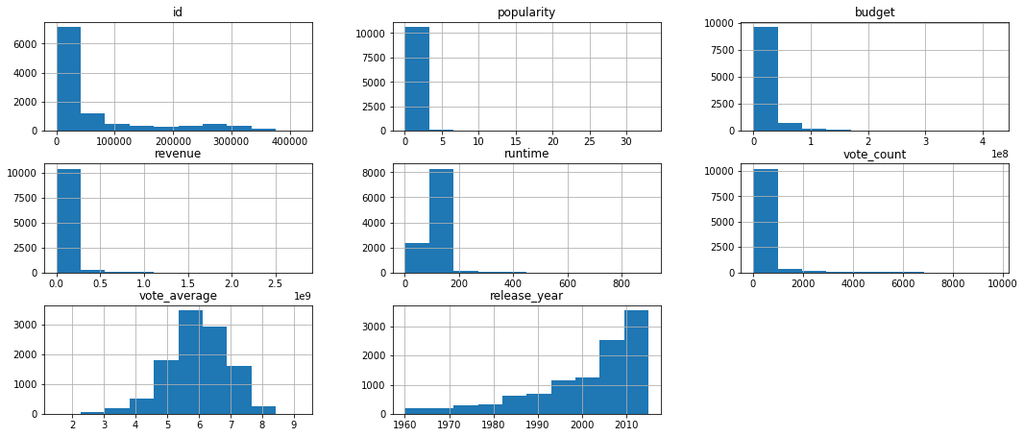

```python
# Use this, and more code cells, to explore your data. Don't forget to add
#   Markdown cells to document your observations and findings.
fetch.hist(figsize=(18,7.5));
```

```python
major = fetch.budget >= fetch.revenue

fetch[major].count()
```

```
id                7023
imdb_id           7023
popularity        7023
budget            7023
revenue           7023
original_title    7023
director          7023
runtime           7023
genres            7023
release_date      7023
vote_count        7023
vote_average      7023
release_year      7023
dtype: int64
```

```python
lower = fetch.budget < fetch.revenue

fetch[lower].count()
```

```
id                3772
imdb_id           3772
popularity        3772
budget            3772
revenue           3772
original_title    3772
director          3772
runtime           3772
genres            3772
release_date      3772
vote_count        3772
vote_average      3772
release_year      3772
dtype: int64
```

Films that have a lower creation budget than revenues are **3772**

### Profit calculation of the movies

```python
#fetch.drop('profit', axis=1, inplace = True)
```

```python
#We will create a new column to insert profit calculation
fetch.insert(3,'profit',fetch.revenue-fetch.budget)
fetch.head(2)
```

|  | id | imdb_id | popularity | profit | budget | revenue | original_title | director | runtime | genres | release_date | vote_count | vote_average | release_year |
| --- | --- | --- | --- | --- | --- | --- | --- | --- | --- | --- | --- | --- | --- | --- |
| 0 | 135397 | tt0369610 | 32.985763 | 1363528810 | 150000000 | 1513528810 | Jurassic World | Colin Trevorrow | 124 | Action\|Adventure\|Science Fiction\|Thriller | 2015-06-09 | 5562 | 6.5 | 2015 |
| 1 | 76341 | tt1392190 | 28.419936 | 228436354 | 150000000 | 378436354 | Mad Max: Fury Road | George Miller | 120 | Action\|Adventure\|Science Fiction\|Thriller | 2015-05-13 | 6185 | 7.1 | 2015 |

### Research Question 1: Which genres are most popular from year to year?

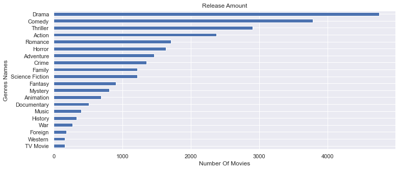

```python
graphs=fetch.genres.str.get_dummies(sep='|')
number_gr=graphs.sum(axis=0).astype(int).sort_values()
number_gr.plot(kind='barh', align='center',figsize=(12,5))
plot.title("Release Amount")
plot.xlabel('Number Of Movies')
plot.ylabel("Genres Names");
```

```python
def getMath(column):
    #Getting highest earned profit
    high= fetch[column].idxmax()
    high_details=ps.DataFrame(fetch.loc[high])

    #Getting lowest earned profit
    low= fetch[column].idxmin()
    low_details=ps.DataFrame(fetch.loc[low])

    #Merging data in one place
    info=ps.concat([high_details, low_details], axis=1)

    return info
```

### Research Question 2: Which movies had lowest price(budget) and largest ?

```python
getMath('budget')
```

|  | 2244 | 30 |
| --- | --- | --- |
| id | 46528 | 280996 |
| imdb_id | tt1032751 | tt3168230 |
| popularity | 0.25054 | 3.927333 |
| profit | -413912431 | 29355203 |
| budget | 425000000 | 0 |
| revenue | 11087569 | 29355203 |
| original_title | The Warrior's Way | Mr. Holmes |
| director | Sngmoo Lee | Bill Condon |
| runtime | 100 | 103 |
| genres | Adventure\|Fantasy\|Action\|Western\|Thriller | Mystery\|Drama |
| release_date | 2010-12-02 00:00:00 | 2015-06-19 00:00:00 |
| vote_count | 74 | 425 |
| vote_average | 6.4 | 6.4 |
| release_year | 2010 | 2015 |

### Research Question 3: What kinds of properties are associated with movies that have high revenues?

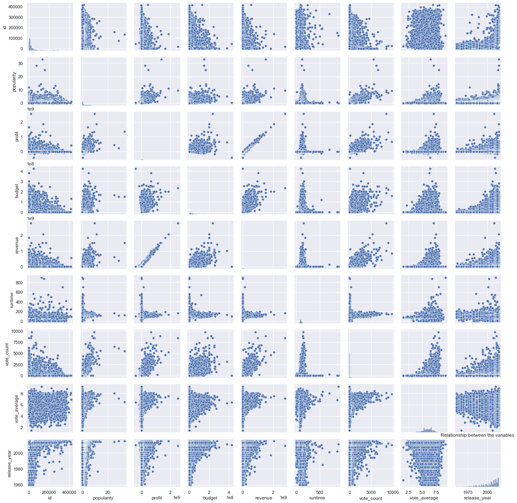

```python
sb.pairplot(fetch, height=2);
plot.title("Relationship between the variables");
```

### Research Question 4: Which movie had the highest or lowest Profit?

```python
getMath('profit')
```

|  | 1386 | 2244 |
| --- | --- | --- |
| id | 19995 | 46528 |
| imdb_id | tt0499549 | tt1032751 |
| popularity | 9.432768 | 0.25054 |
| profit | 2544505847 | -413912431 |
| budget | 237000000 | 425000000 |
| revenue | 2781505847 | 11087569 |
| original_title | Avatar | The Warrior's Way |
| director | James Cameron | Sngmoo Lee |
| runtime | 162 | 100 |
| genres | Action\|Adventure\|Fantasy\|Science Fiction | Adventure\|Fantasy\|Action\|Western\|Thriller |
| release_date | 2009-12-10 00:00:00 | 2010-12-02 00:00:00 |
| vote_count | 8458 | 74 |
| vote_average | 7.1 | 6.4 |
| release_year | 2009 | 2010 |

Accoding with information above, The movie with Most profit is **Avatar** and with least is **The Warrior's Way**

```python
#We can fetch the best 5 position instead of showing the lowest and high
def getTop5(column,size=5):
    fetch_sorted = ps.DataFrame(fetch[column].sort_values(ascending=False))[:size]
    fetch_sorted['original_title'] = fetch['original_title']
    plot.figure(figsize=(12,6))
    #Calculate the avarage
    avg = np.mean(fetch[column])
    sb.barplot(x=column, y='original_title', data=fetch_sorted, label=column)
    plot.axvline(avg, color='k', linestyle='--', label='mean')
    if (column == 'profit' or column == 'budget' or column == 'revenue'):
        plot.xlabel(column.capitalize() + ' (MZN - Metical)')
    else:
        plot.xlabel(column.capitalize())
    plot.ylabel('')
    plot.title('Top 5 Movies in: ' + column.capitalize())
    plot.legend()
```

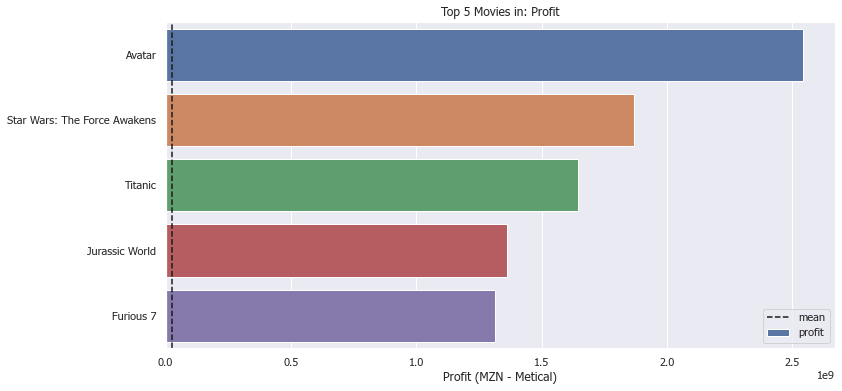

```python
getTop5('profit')
```

### Research Question 5: Which year had the highest release of movies?

```python
#Group the movies by release year and count them
y=fetch.groupby('release_year')['original_title'].count()
x=np.arange(1960, 2022,5)
```

```python
#Finding out the year with highest release
y.idxmax()
```

```
2014
```

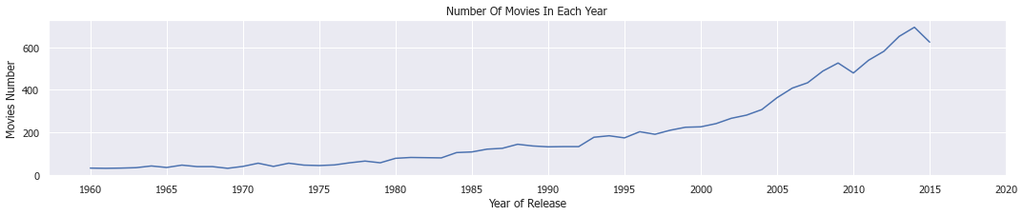

```python
sb.set(style='darkgrid', palette='deep', font='tahoma', font_scale=1)
plot.figure(figsize=(18, 3))
plot.plot(y)
plot.title("Number Of Movies In Each Year")
plot.xticks(x)
plot.xlabel('Year of Release')
plot.ylabel('Movies Number');
```

**2014** is the year with the highest number of released movies

### Research Question 6: Which Movie had longest and shortest runtime?

```python
getMath('runtime')
```

|  | 3894 | 92 |
| --- | --- | --- |
| id | 125336 | 370687 |
| imdb_id | tt2044056 | tt3608646 |
| popularity | 0.006925 | 1.876037 |
| profit | 0 | 0 |
| budget | 0 | 0 |
| revenue | 0 | 0 |
| original_title | The Story of Film: An Odyssey | Mythica: The Necromancer |
| director | Mark Cousins | A. Todd Smith |
| runtime | 900 | 0 |
| genres | Documentary | Fantasy\|Action\|Adventure |
| release_date | 2011-09-03 00:00:00 | 2015-12-19 00:00:00 |
| vote_count | 14 | 11 |
| vote_average | 9.2 | 5.4 |
| release_year | 2011 | 2015 |

## Conclusions

> I had a limitation to make the relationship between the budget used on production and its popularity.

```python
from subprocess import call
call(['python', '-m', 'nbconvert', 'Investigate_a_Dataset.ipynb'])
```

```
4294967295
```